# EDA of Monica Dataset

DATAPROS

# Inspect dataset: Data Dictionary

```
##  [1] "X"        "outcome"  "sex"      "age"      "yronset"  "premi"
##  [7] "smstat"   "diabetes" "highbp"   "hichol"   "angina"   "stroke"
## [13] "hosp"
```

```
## 'data.frame':    6367 obs. of  13 variables:
##  $ X       : int  1 2 3 4 5 6 7 8 9 10 ...
##  $ outcome : chr  "live" "live" "live" "live" ...
##  $ sex     : chr  "f" "m" "m" "m" ...
##  $ age     : int  63 59 68 46 48 55 56 68 69 64 ...
##  $ yronset : int  85 85 85 85 85 85 85 85 85 85 ...
##  $ premi   : chr  "n" "y" "n" "n" ...
##  $ smstat  : chr  "x" "x" "n" "c" ...
##  $ diabetes: chr  "n" "n" "n" "n" ...
##  $ highbp  : chr  "y" "y" "y" "n" ...
##  $ hichol  : chr  "y" "n" "n" "n" ...
##  $ angina  : chr  "n" "n" "n" "n" ...
##  $ stroke  : chr  "n" "n" "n" "n" ...
##  $ hosp    : chr  "y" "y" "y" "y" ...
```

Dataframe with 13 variables (including X, counter of number of samples) and 6367 samples.

**Inspect the 10 columns with data type characters**

```
## [1] "outcome"
```

```
##
## dead live
## 2842 3525
```

```
## [1] "sex"
```

```
##
##    f    m
## 1762 4605
```

```
## [1] "premi"
```

```
##
##    n   nk    y
## 4122  734 1511
```

```
## [1] "smstat"
```

```
##
##    c    n   nk    x
## 2051 1460  918 1938
```

```
## [1] "diabetes"
```

```
##
##    n   nk    y
## 4664  885  818
```

```
## [1] "highbp"
```

```
##
##    n   nk    y
## 2542  948 2877
```

```
## [1] "hicol"
```

```
##
##    n   nk    y
## 3294 1233 1840
```

```
## [1] "angina"
```

```
##
##    n   nk    y
## 3473  975 1919
```

```
## [1] "stroke"
```

```
##
##    n   nk    y
## 4881  926  560
```

```
## [1] "hosp"
```

```
##
##    n    y
## 1925 4442
```

Large number of Not Known (“nk”) values in 7 columns: “premi”,“smstat”,“diabetes”,“highbp”,“hichol”,“angina” and “stroke”

3 Columns with complete info: “outcome”, “sex” and “hosp”

**Inspect the 2 columns with data type numeric**

```
##    Min. 1st Qu.  Median    Mean 3rd Qu.    Max.
##   35.00   55.00   61.00   59.42   66.00   69.00
```

```
##    Min. 1st Qu.  Median    Mean 3rd Qu.    Max.
##   85.00   87.00   89.00   88.75   91.00   93.00
```

**Drop column 1**

Drop redundant column (column # 1). Check operation.

```
## 'data.frame':    6367 obs. of  12 variables:
##  $ outcome : chr  "live" "live" "live" "live" ...
##  $ sex     : chr  "f" "m" "m" "m" ...
##  $ age     : int  63 59 68 46 48 55 56 68 69 64 ...
##  $ yronset : int  85 85 85 85 85 85 85 85 85 85 ...
##  $ premi   : chr  "n" "y" "n" "n" ...
##  $ smstat  : chr  "x" "x" "n" "c" ...
##  $ diabetes: chr  "n" "n" "n" "n" ...
##  $ highbp  : chr  "y" "y" "y" "n" ...
##  $ hichol  : chr  "y" "n" "n" "n" ...
##  $ angina  : chr  "n" "n" "n" "n" ...
##  $ stroke  : chr  "n" "n" "n" "n" ...
##  $ hosp    : chr  "y" "y" "y" "y" ...
```

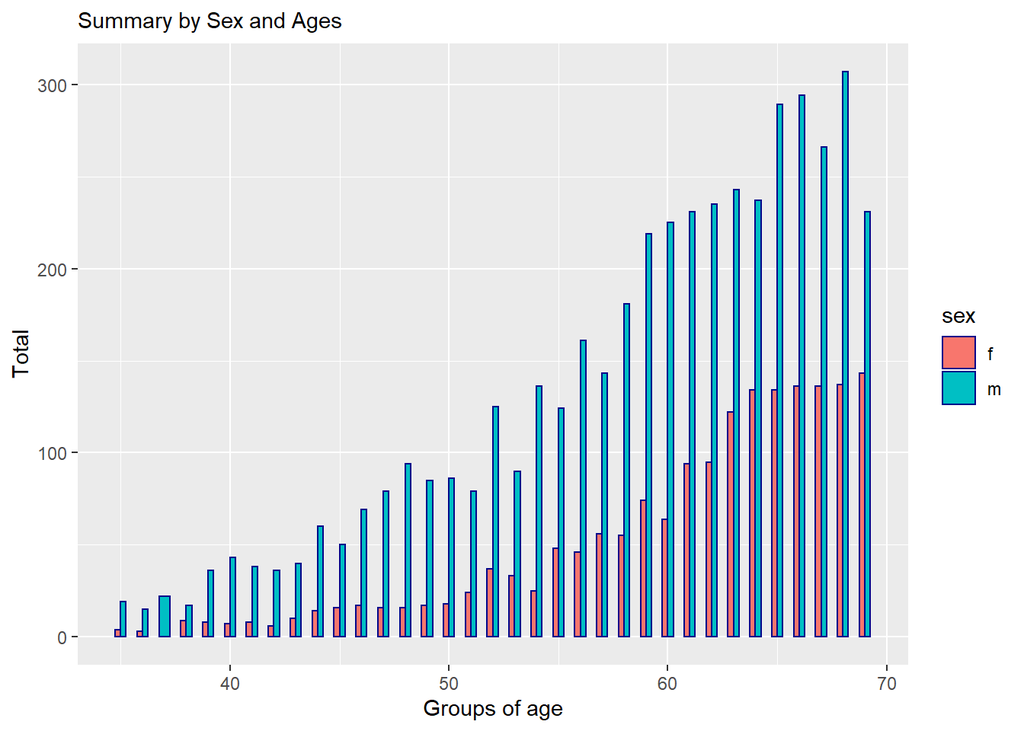

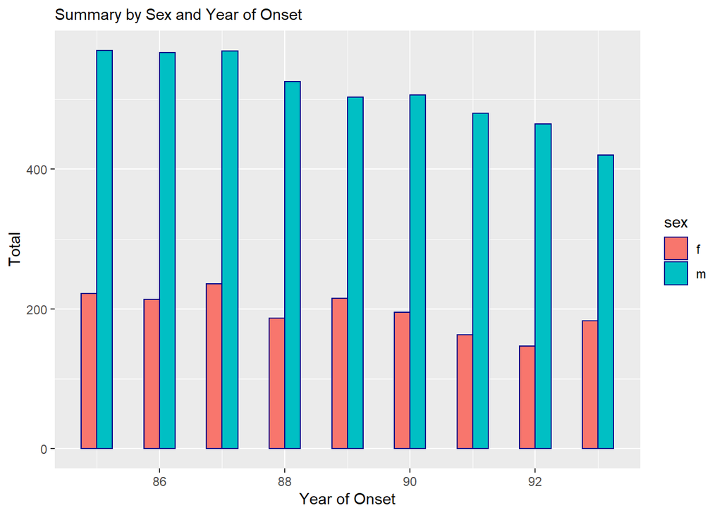

# Inspect distributions

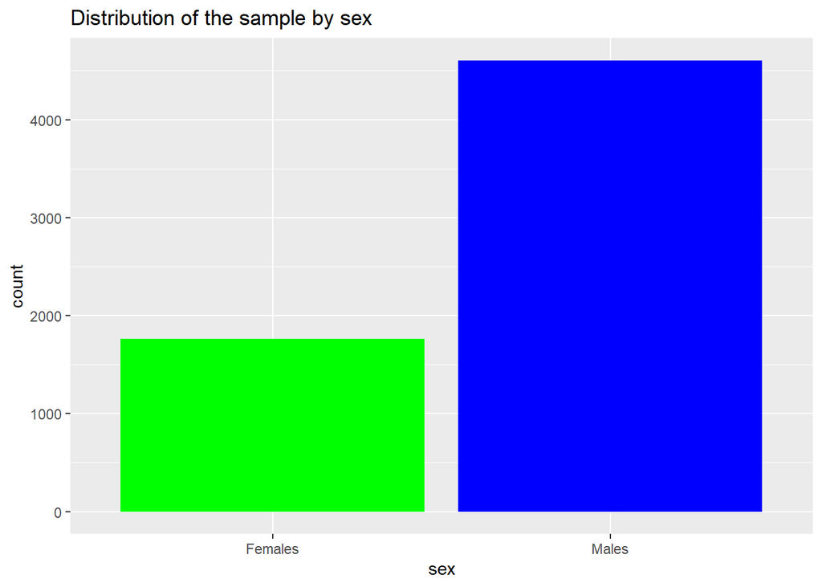

The data sample is skewed towards men.

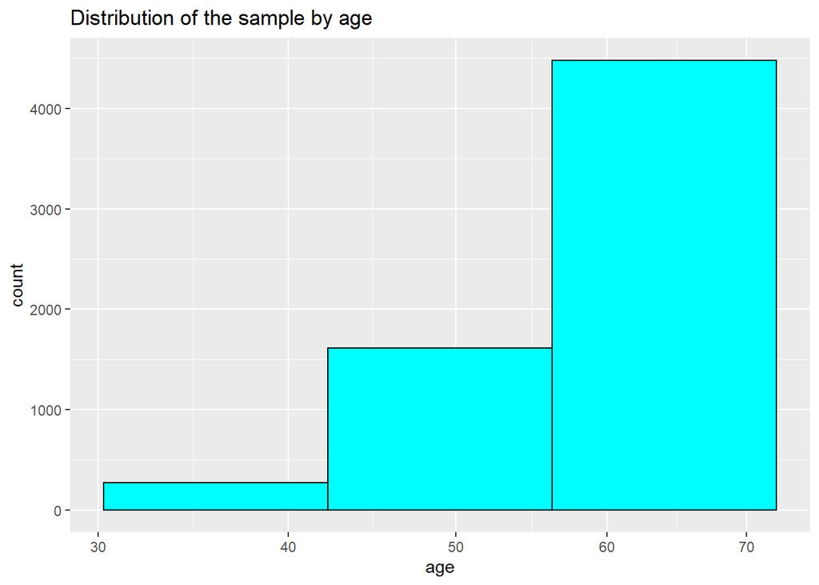

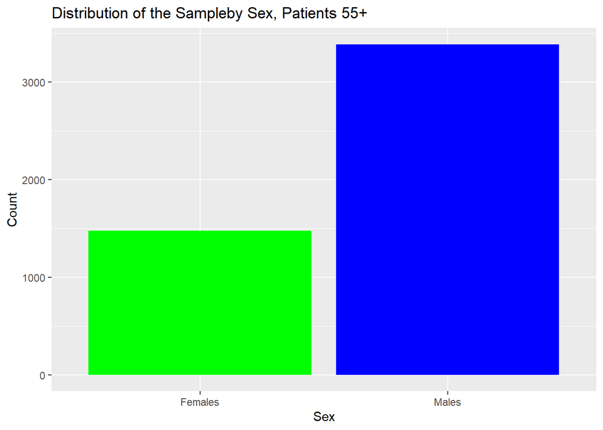

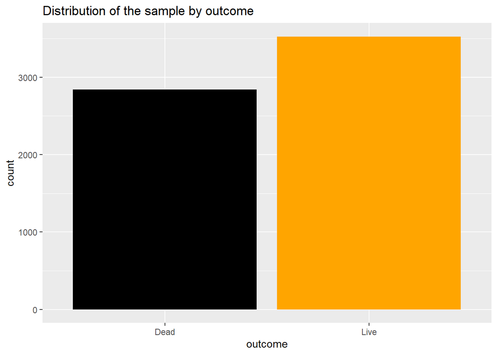

[figure not shown]

[figure not shown]

[figure not shown]

[figure not shown]

[figure not shown]

[figure not shown]

[figure not shown]

[figure not shown]

**Summary**

The variables with complete information are: Sex, Age, Outcome, Hospitalization, and Year of Onset.

# Univariate analysis

**Prepare Dataset for Chi-Square**

```
## 'data.frame':    6367 obs. of  12 variables:
##  $ outcome : chr  "live" "live" "live" "live" ...
##  $ sex     : chr  "f" "m" "m" "m" ...
##  $ age     : int  63 59 68 46 48 55 56 68 69 64 ...
##  $ yronset : int  85 85 85 85 85 85 85 85 85 85 ...
##  $ premi   : chr  "n" "y" "n" "n" ...
##  $ smstat  : chr  "x" "x" "n" "c" ...
##  $ diabetes: chr  "n" "n" "n" "n" ...
##  $ highbp  : chr  "y" "y" "y" "n" ...
##  $ hichol  : chr  "y" "n" "n" "n" ...
##  $ angina  : chr  "n" "n" "n" "n" ...
##  $ stroke  : chr  "n" "n" "n" "n" ...
##  $ hosp    : chr  "y" "y" "y" "y" ...
```

```
##
##    n    y
## 4122 1511
```

```
##
##    c    n    x
## 2051 1460 1938
```

```
##
##    n    y
## 4664  818
```

```
##
##    n    y
## 2542 2877
```

```
##
##    n    y
## 3294 1840
```

```
##
##    n    y
## 3473 1919
```

```
##
##    n    y
## 4881  560
```

**Chi-Square for Each Categorical Variable by Outcome**

This variable was not modified, was already complete. p-value should be 0.9997 amd it is.

**Sex and Outcome**

```
##
##  Pearson's Chi-squared test with Yates' continuity correction
##
## data:  table11
## X-squared = 1.349e-07, df = 1, p-value = 0.9997
```

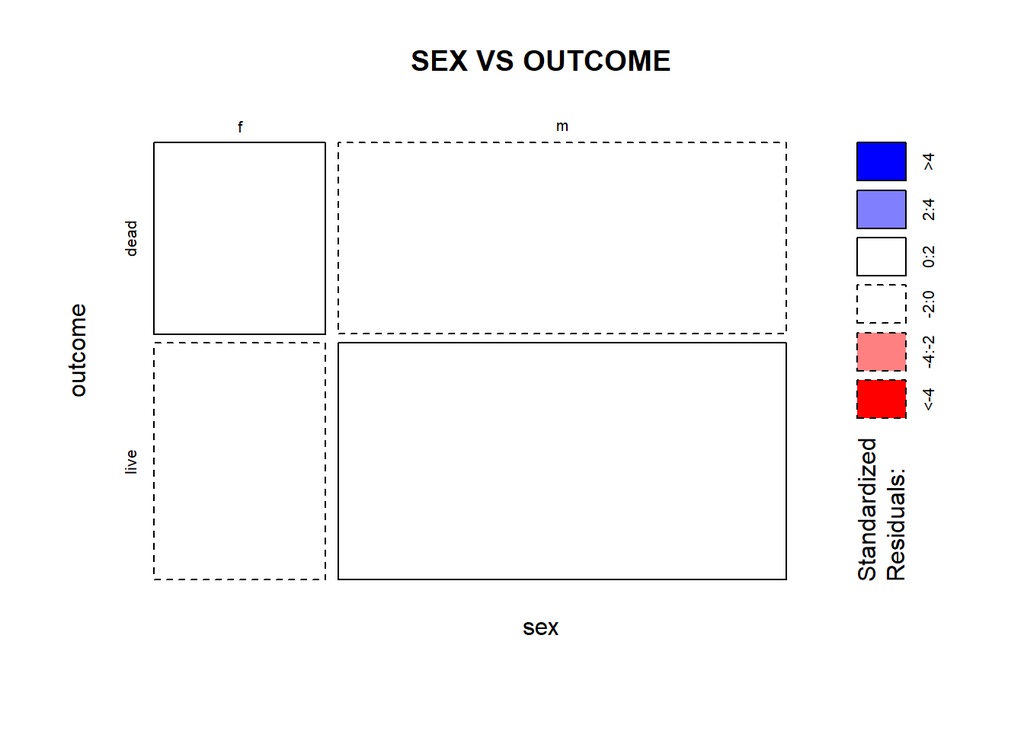

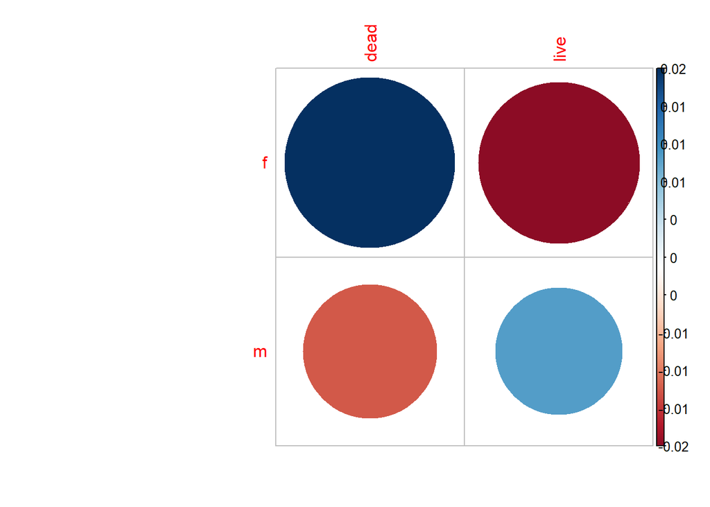

The null hypothesis H0 is Sex and Outcome are independent.

p-value is greater than 0.05.

Therefore, we fail to reject the null hypothesis.

**Previous Myocardial Infarction event and Outcome**

This variable was modified, nk replaced with NA. p-value of subset is 0.001374. We get the same.

```
##
##  Pearson's Chi-squared test with Yates' continuity correction
##
## data:  table12
## X-squared = 10.24, df = 1, p-value = 0.001374
```

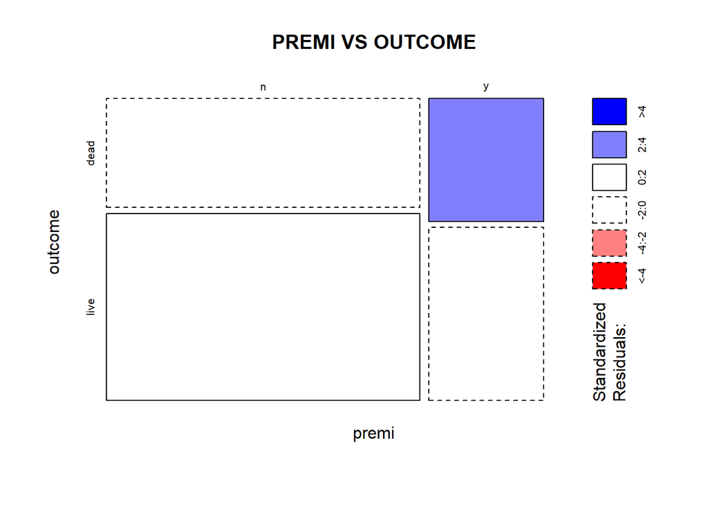

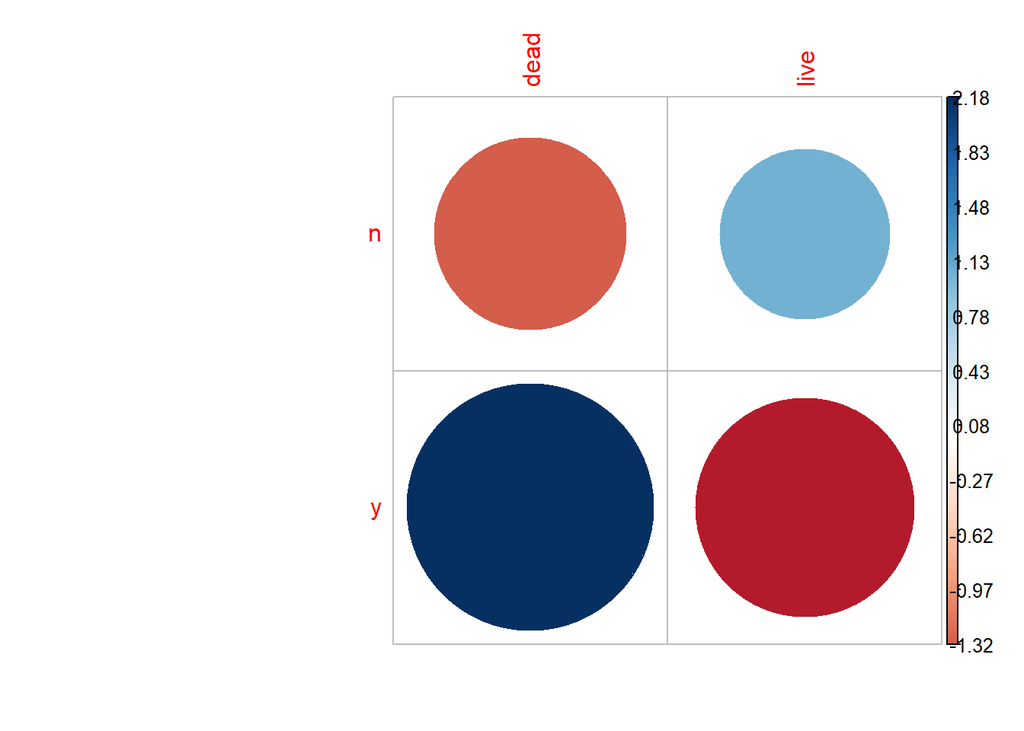

The null hypothesis H0 is Previous Myocardial Infarction event and Outcome are independent.

p-value is smaller than 0.05.

Therefore, we reject the null hypothesis H0 and conclude that Previous Myocardial Infarction event and Outcome are not significantly independent.

**Smoking status and Outcome**

This variable was modified, nk replaced with NA. p-value of subset is 0.03172. We get the same.

```
##
##  Pearson's Chi-squared test
##
## data:  table13
## X-squared = 6.9016, df = 2, p-value = 0.03172
```

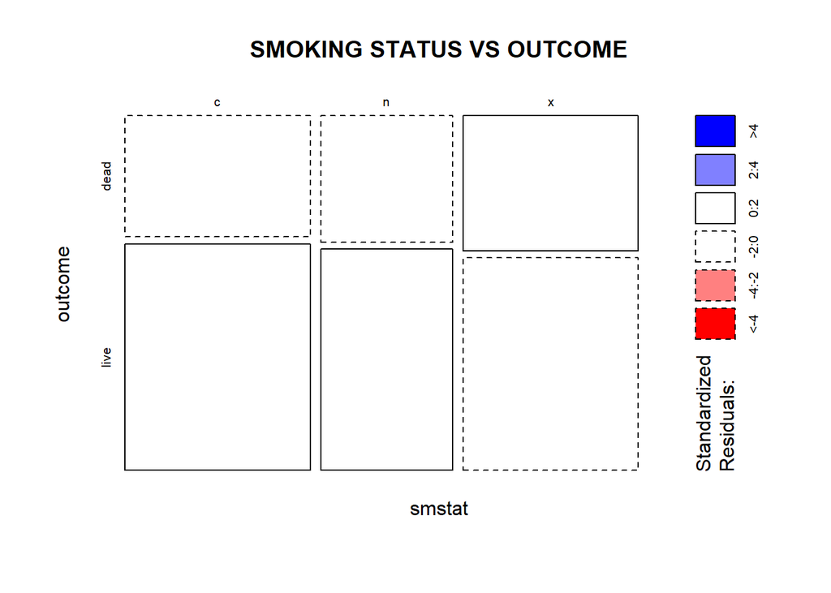

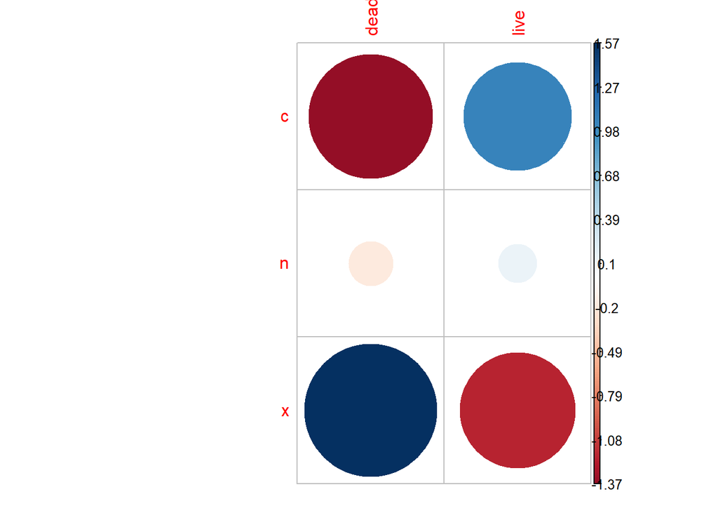

The null hypothesis H0 is Smoking status and Outcome are independent.

p-value is smaller than 0.05.

Therefore, we reject the null hypothesis H0 and conclude that Smoking status and Outcome are not significantly independent.

**Diabetes and Outcome**

This variable was modified, nk replaced with NA. p-value of subset is 5.472e-05. We get the same.

```
##
##  Pearson's Chi-squared test with Yates' continuity correction
##
## data:  table14
## X-squared = 16.277, df = 1, p-value = 5.472e-05
```

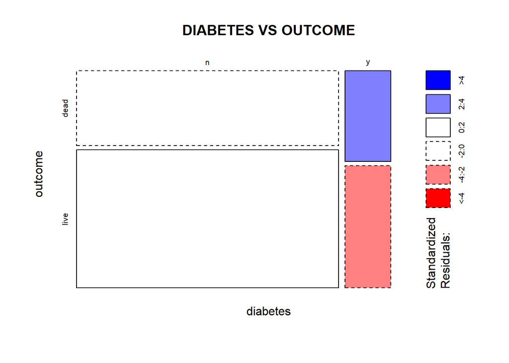

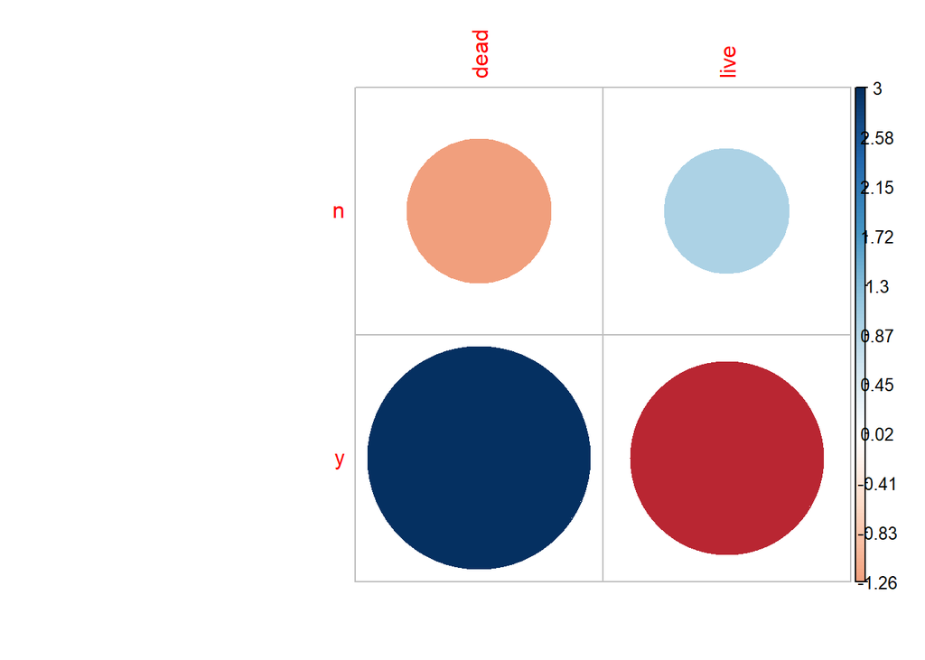

The null hypothesis H0 is Diabetes and Outcome are independent.

p-value is significantly smaller than 0.05.

Therefore, we reject the null hypothesis H0 and conclude that Diabetes and Outcome are not significantly independent.

**High Blood Pressure and Outcome**

This variable was modified, nk replaced with NA. p-value of subset is 0.1915. We get the same.

```
##
##  Pearson's Chi-squared test with Yates' continuity correction
##
## data:  table15
## X-squared = 1.7057, df = 1, p-value = 0.1915
```

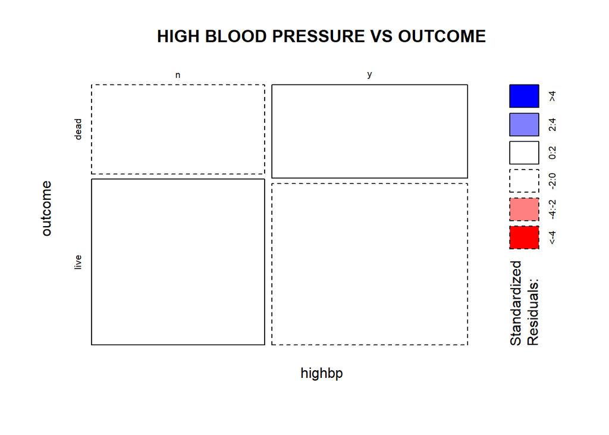

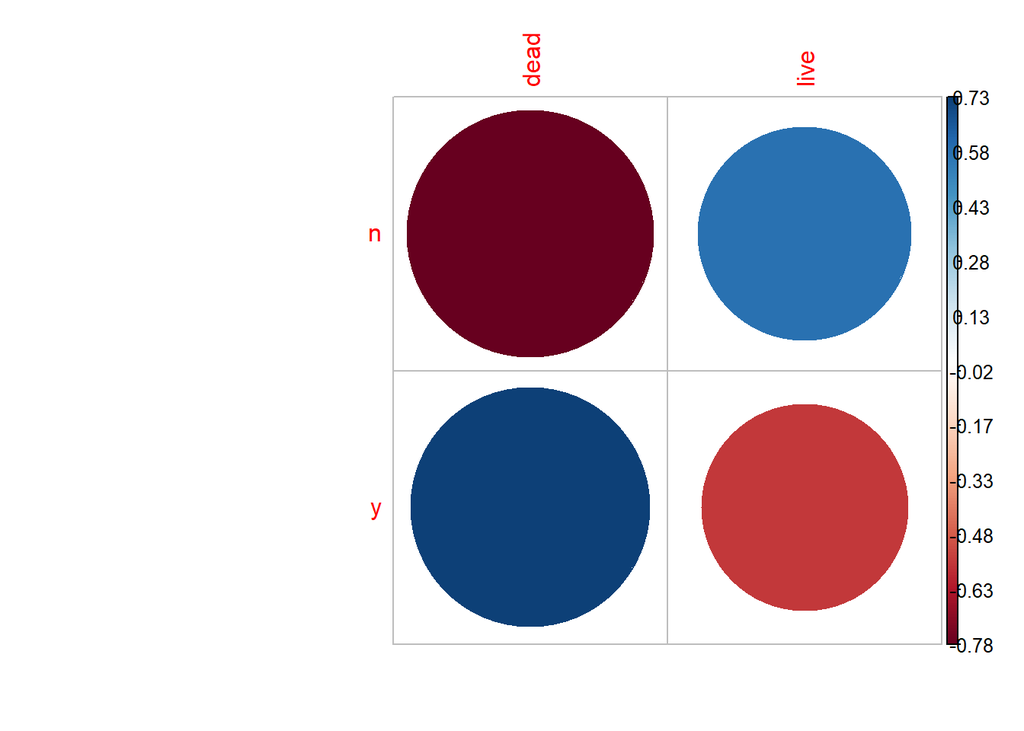

The null hypothesis H0 is High Blood Pressure and Outcome are independent.

p-value is gretaer than 0.05.

Therefore, we fail to reject the null hypothesis H0.

**High Cholesterol and Outcome**

This variable was modified, nk replaced with NA. p-value of subset is 1.182e-10. We get the same.

```
##
##  Pearson's Chi-squared test with Yates' continuity correction
##
## data:  table16
## X-squared = 41.495, df = 1, p-value = 1.182e-10
```

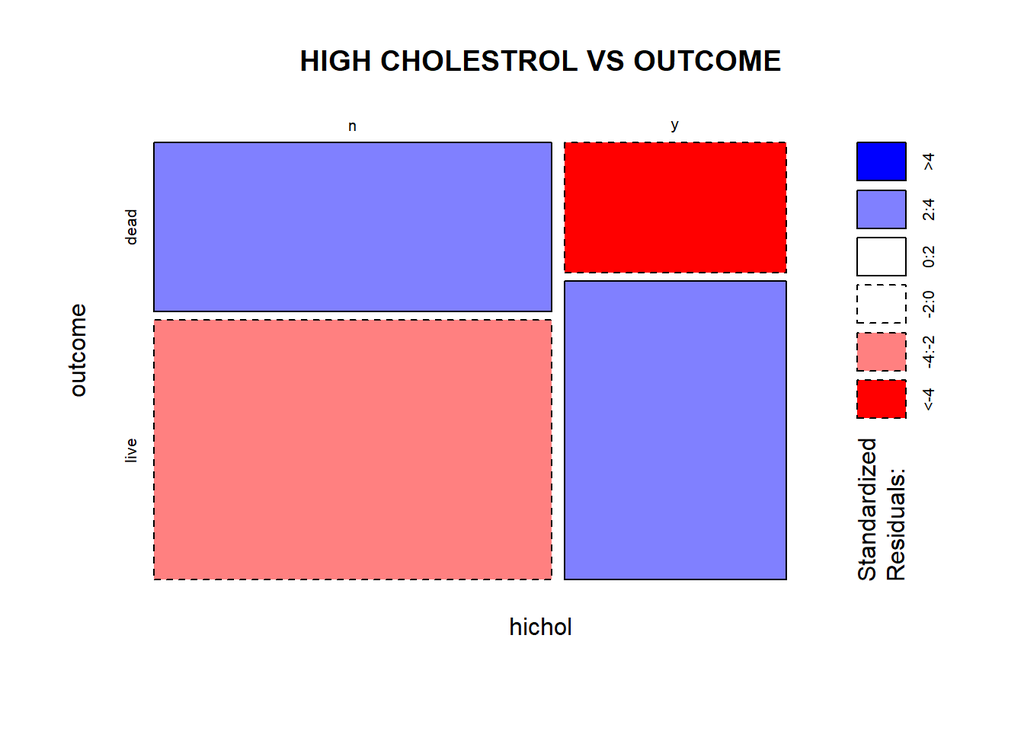

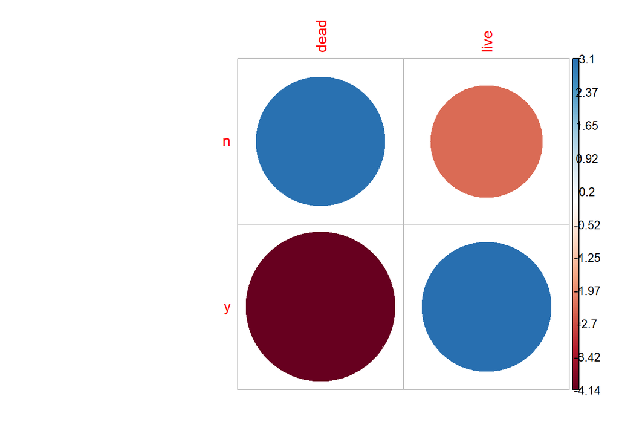

The null hypothesis H0 is High Cholesterol and Outcome are independent.

p-value is significantly smaller than 0.05.

Therefore, we reject the null hypothesis H0 and conclude that High Cholesterol and Outcome are not significantly independent.

**Angina and Outcome**

This variable was modified, nk replaced with NA. p-value of subset is 2.137e-07. We get the same.

```
##
##  Pearson's Chi-squared test with Yates' continuity correction
##
## data:  table17
## X-squared = 26.905, df = 1, p-value = 2.137e-07
```

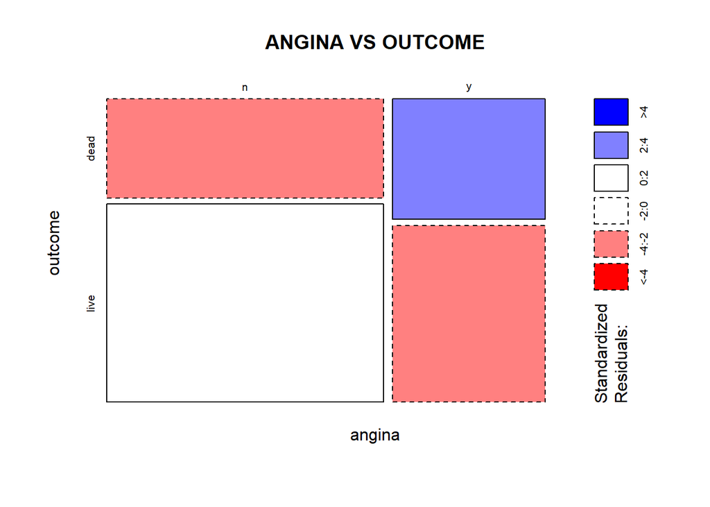

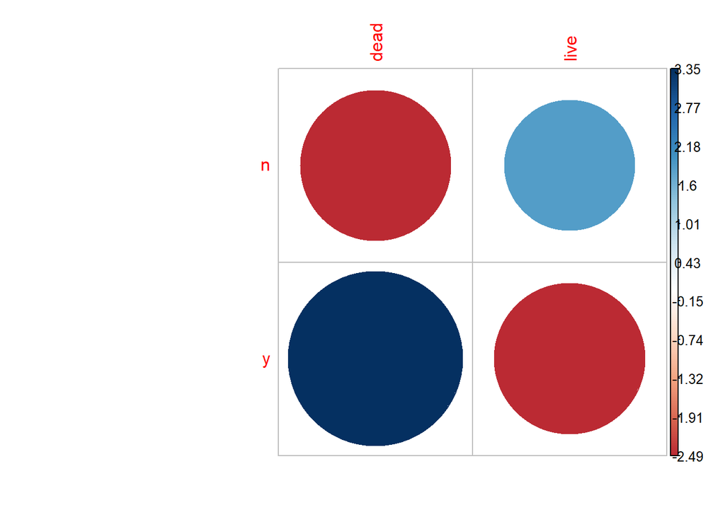

The null hypothesis H0 is Angina and Outcome are independent.

p-value is significantly smaller than 0.05.

Therefore, we reject the null hypothesis H0 and conclude that Angina and Outcome are not significantly independent.

**Stroke and Outcome**

This variable was modified, nk replaced with NA. p-value of subset is 3.897e-13. We get the same.

```
##
##  Pearson's Chi-squared test with Yates' continuity correction
##
## data:  table18
## X-squared = 52.694, df = 1, p-value = 3.897e-13
```

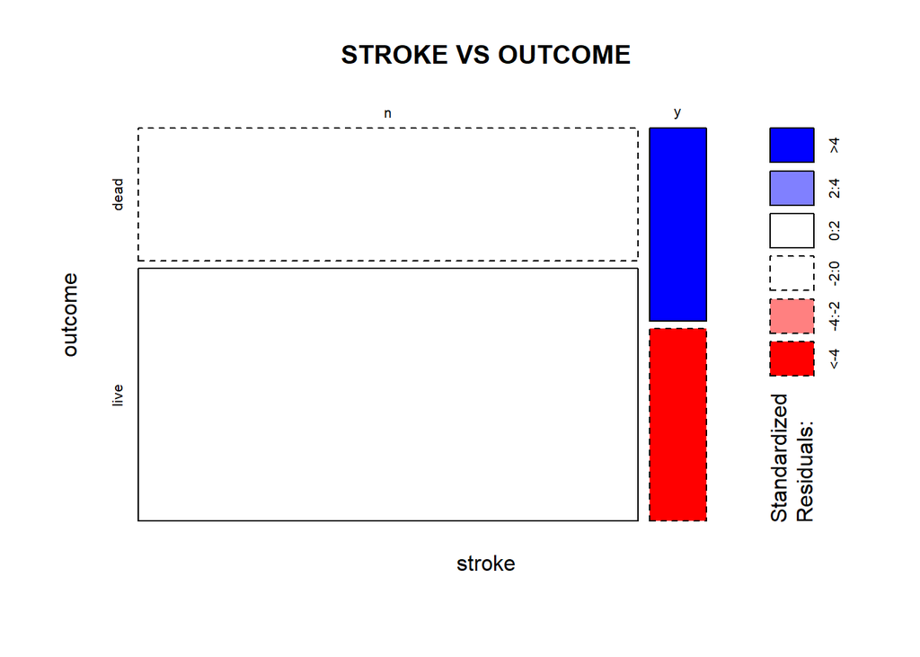

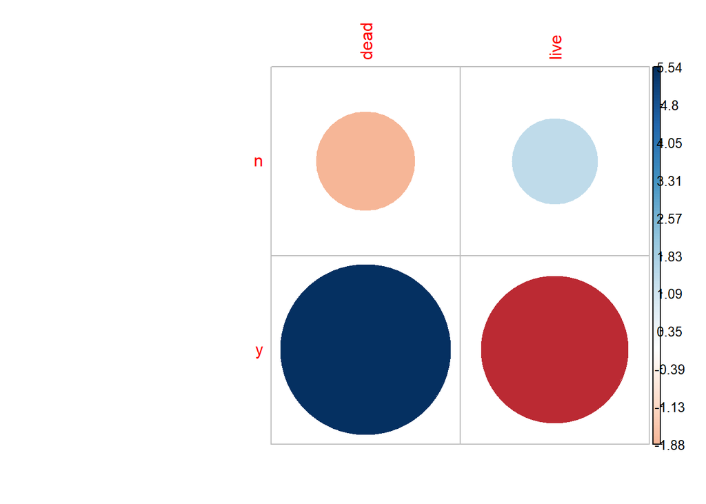

The null hypothesis H0 is Stroke and Outcome are independent.

p-value is significantly smaller than 0.05.

Therefore, we reject the null hypothesis H0 and conclude that Stroke and Outcome are not significantly independent.

**Hospitalization and Outcome**

This variable was not modified, was already complete. p-value should be < 2.2e-16 amd it is.

```
##
##  Pearson's Chi-squared test with Yates' continuity correction
##
## data:  table19
## X-squared = 3399.9, df = 1, p-value < 2.2e-16
```

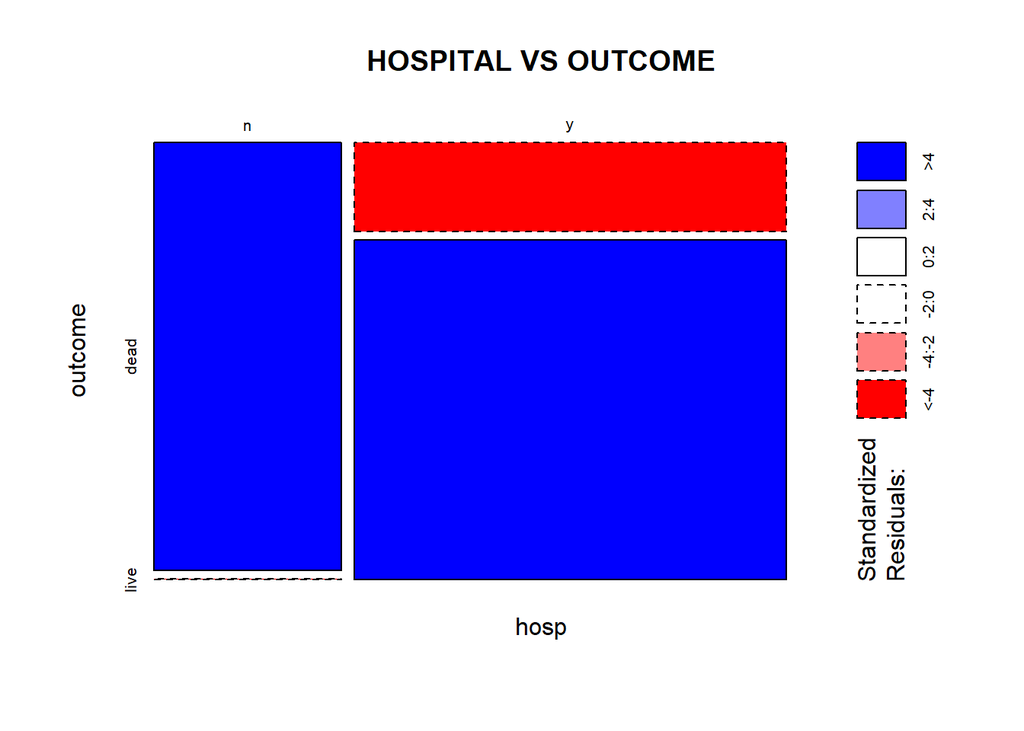

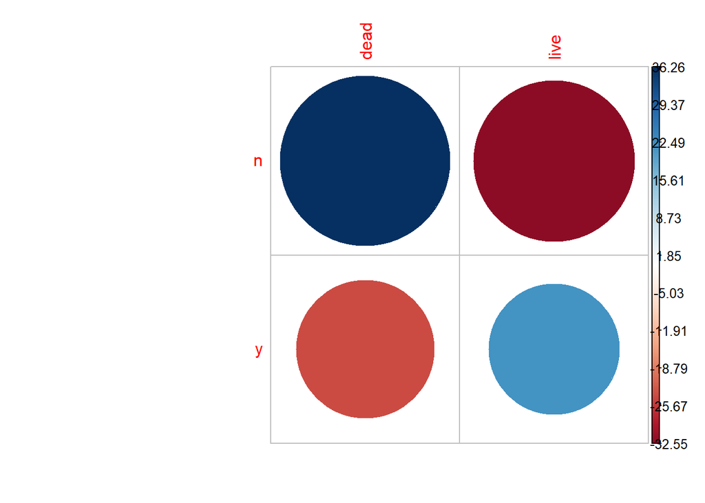

The null hypothesis H0 is Hospitalization and Outcome are independent.

p-value is significanly smaller than 0.05.

Therefore, we reject the null hypothesis H0 and conclude that Hospitalization and Outcome are not significantly independent.

# Summary of univariate analysis

Variables for which we reject the null hypothesis Ho and conclude that they are not significantly independent: Previous Myocardial Infarction, Smoking Status, Diabetes, High Cholesterol, Angina, Stroke and Hospitalization.

Among these variables, p-value is significantly smaller for: Diabetes, High Cholesterol, Angina, Stroke and Hospitalization.

Variables for which we fail to reject the null hypothesis: Sex and High Blood Pressure.

**Summary of Risk Factors**

[output not shown]

# Univariate analysis stratified by Sex

```
## 'data.frame':    1762 obs. of  12 variables:
##  $ outcome : chr  "live" "live" "live" "live" ...
##  $ sex     : chr  "f" "f" "f" "f" ...
##  $ age     : int  63 55 68 64 67 66 63 68 46 66 ...
##  $ yronset : int  85 85 85 85 85 85 85 85 85 85 ...
##  $ premi   : chr  "n" "n" "y" "n" ...
##  $ smstat  : chr  "x" "c" NA "x" ...
##  $ diabetes: chr  "n" "n" NA "n" ...
##  $ highbp  : chr  "y" "y" "y" "y" ...
##  $ hichol  : chr  "y" "y" NA "n" ...
##  $ angina  : chr  "n" "n" "y" "y" ...
##  $ stroke  : chr  "n" "n" "n" "n" ...
##  $ hosp    : chr  "y" "y" "y" "y" ...
```

```
## 'data.frame':    4605 obs. of  12 variables:
##  $ outcome : chr  "live" "live" "live" "dead" ...
##  $ sex     : chr  "m" "m" "m" "m" ...
##  $ age     : int  59 68 46 48 56 69 55 59 68 48 ...
##  $ yronset : int  85 85 85 85 85 85 85 85 85 85 ...
##  $ premi   : chr  "y" "n" "n" "n" ...
##  $ smstat  : chr  "x" "n" "c" "n" ...
##  $ diabetes: chr  "n" "n" "n" "y" ...
##  $ highbp  : chr  "y" "y" "n" "n" ...
##  $ hichol  : chr  "n" "n" "n" "n" ...
##  $ angina  : chr  "n" "n" "n" "y" ...
##  $ stroke  : chr  "n" "n" "n" "n" ...
##  $ hosp    : chr  "y" "y" "y" "y" ...
```

**Sex and Outcome by Sex**

Female

```
##
##  Chi-squared test for given probabilities
##
## data:  table22.1
## X-squared = 20.059, df = 1, p-value = 7.509e-06
```

Male

```
##
##  Chi-squared test for given probabilities
##
## data:  table22.2
## X-squared = 53.208, df = 1, p-value = 3e-13
```

Same conclusion for female and male.

**Previous Myocardial Infarction and Outcome by Sex**

Female

```
##
##  Pearson's Chi-squared test with Yates' continuity correction
##
## data:  table23.1
## X-squared = 0.19703, df = 1, p-value = 0.6571
```

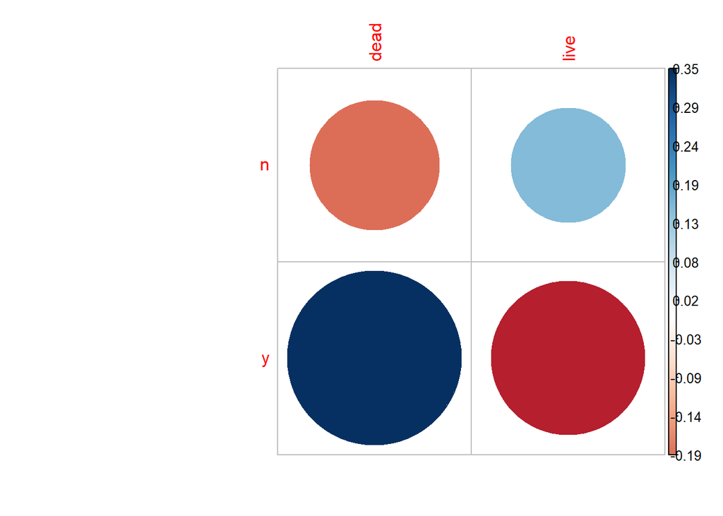

Male

```
##
##  Pearson's Chi-squared test with Yates' continuity correction
##
## data:  table23.2
## X-squared = 11.543, df = 1, p-value = 0.00068
```

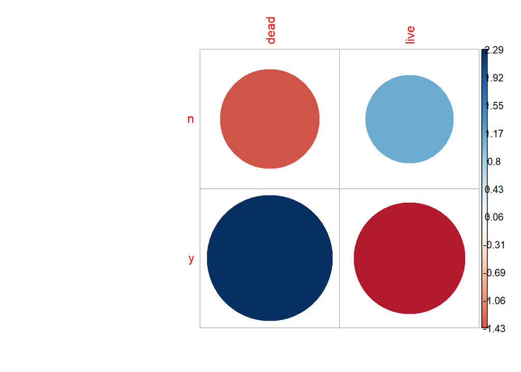

Different conclusion for female and male!

**Smoking Status and Outcome by Sex**

Female

```
##
##  Pearson's Chi-squared test
##
## data:  table24.1
## X-squared = 2.7719, df = 2, p-value = 0.2501
```

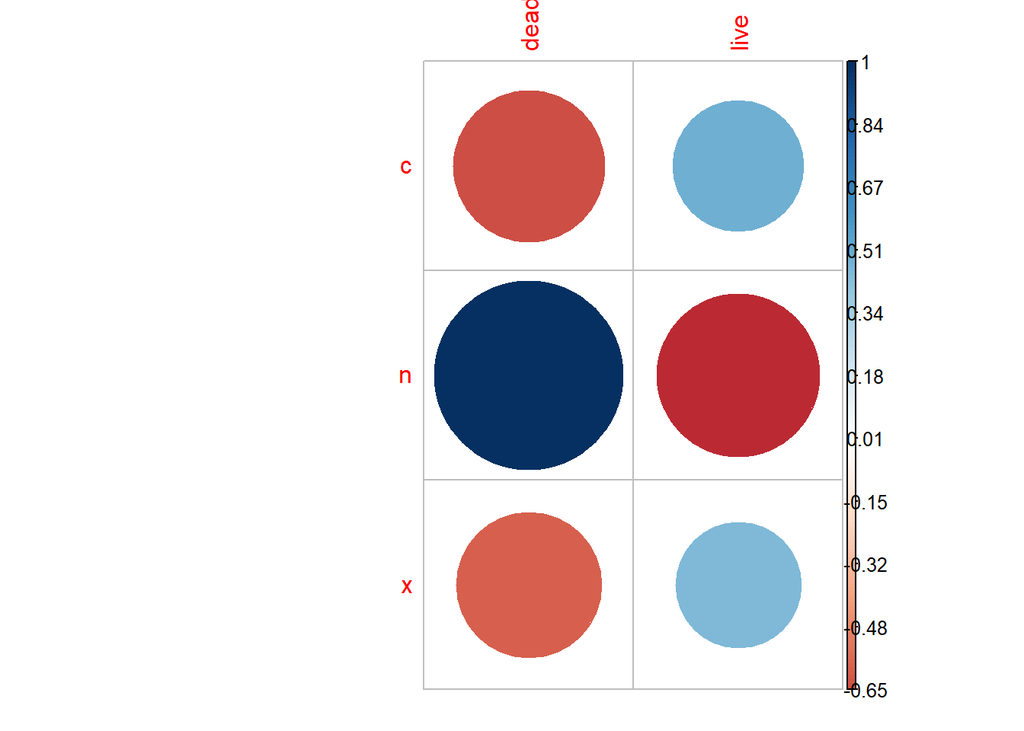

Male

```
##
##  Pearson's Chi-squared test
##
## data:  table24.2
## X-squared = 9.6294, df = 2, p-value = 0.00811
```

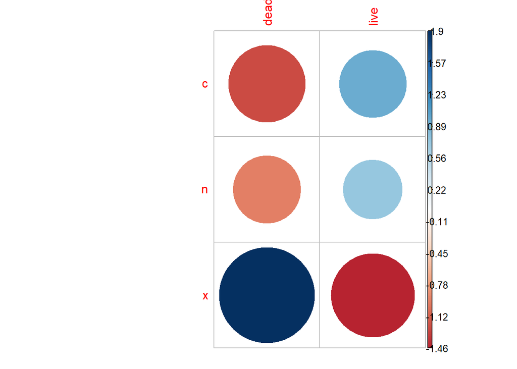

Different conclusion for female and male!

**Diabetes and Outcome by Sex**

Female

```
##
##  Pearson's Chi-squared test with Yates' continuity correction
##
## data:  table25.1
## X-squared = 7.1737, df = 1, p-value = 0.007398
```

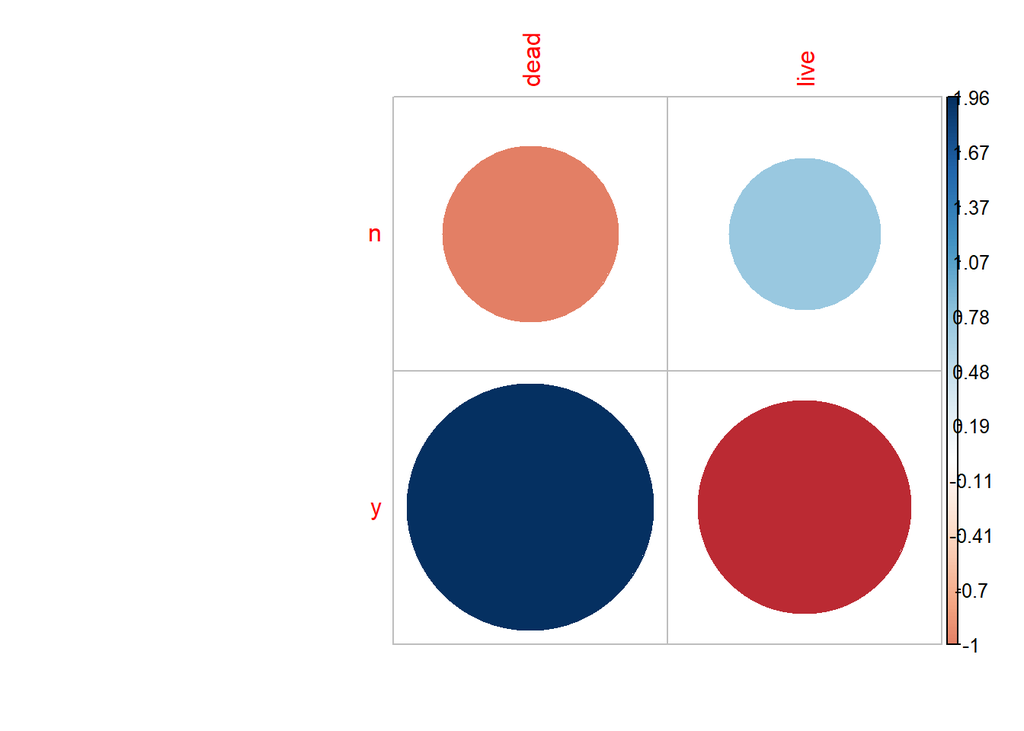

Male

```
##
##  Pearson's Chi-squared test with Yates' continuity correction
##
## data:  table25.2
## X-squared = 9.4292, df = 1, p-value = 0.002136
```

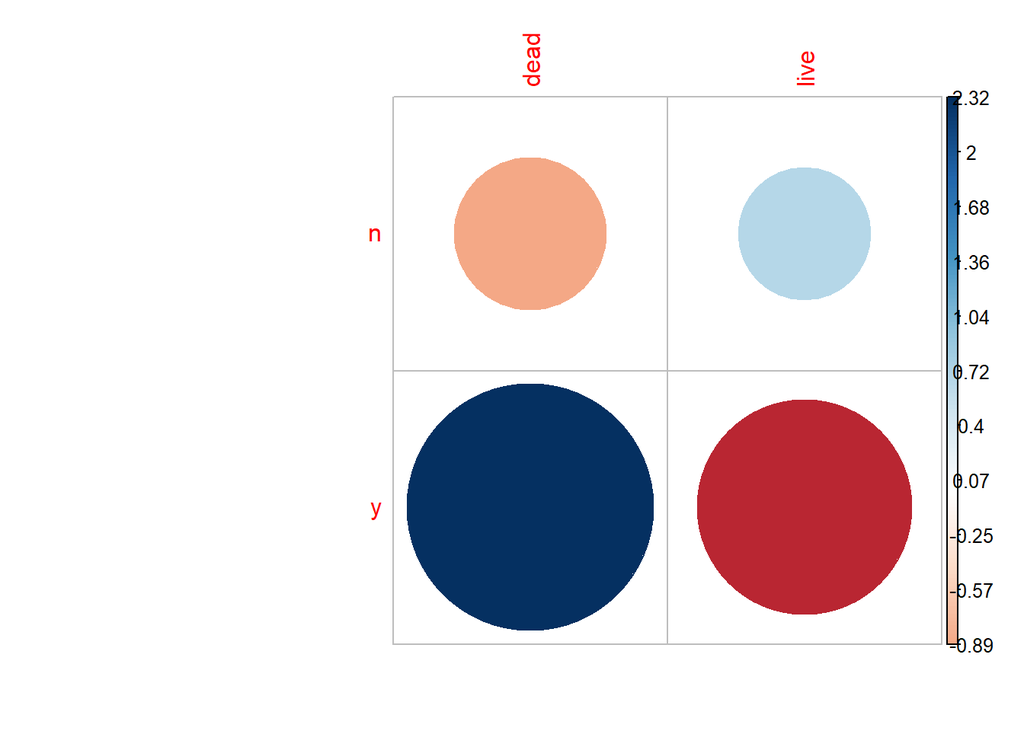

Same conclusion for female and male.

**High Blood Pressure and Outcome by Sex**

Female

```
##
##  Pearson's Chi-squared test with Yates' continuity correction
##
## data:  table26.1
## X-squared = 0.16933, df = 1, p-value = 0.6807
```

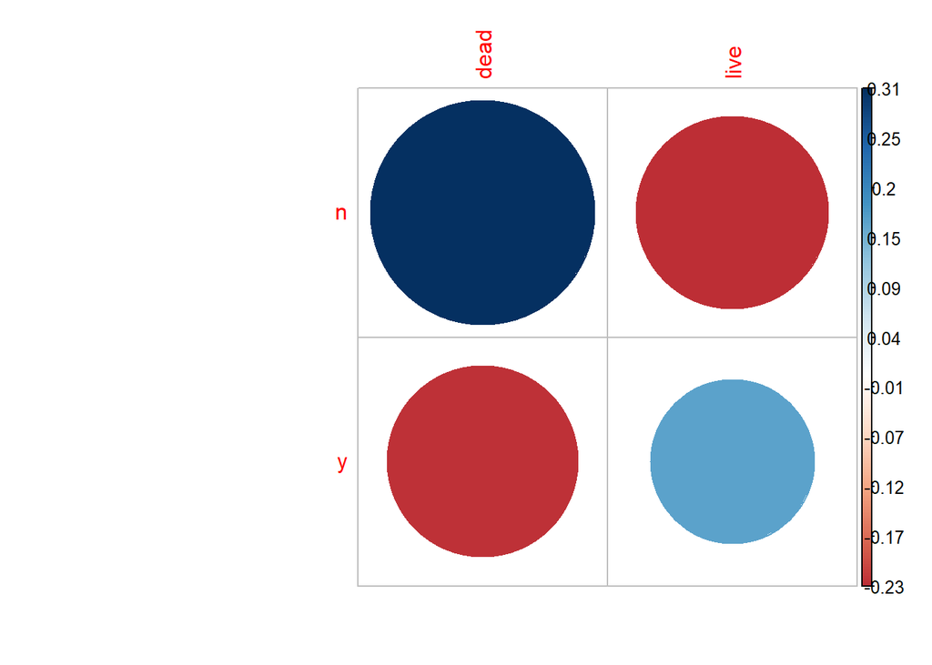

Male

```
##
##  Pearson's Chi-squared test with Yates' continuity correction
##
## data:  table26.2
## X-squared = 3.5735, df = 1, p-value = 0.05871
```

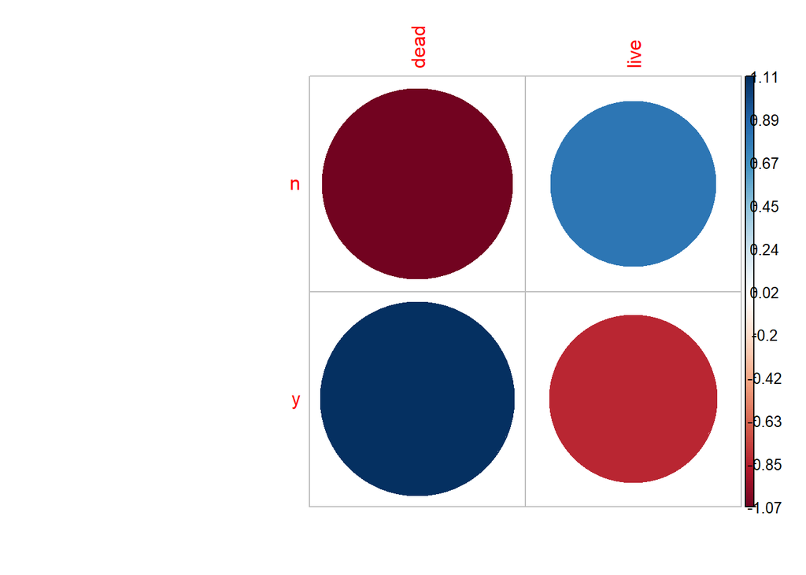

Same conclusion for female and male.

**High Cholesterol and Outcome by Sex**

Female

```
##
##  Pearson's Chi-squared test with Yates' continuity correction
##
## data:  table27.1
## X-squared = 27.938, df = 1, p-value = 1.253e-07
```

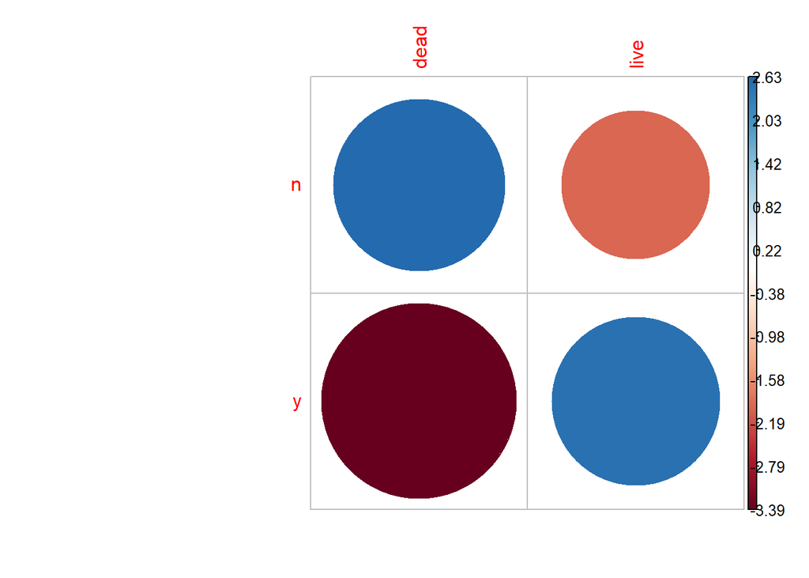

Male

```
##
##  Pearson's Chi-squared test with Yates' continuity correction
##
## data:  table27.2
## X-squared = 18.263, df = 1, p-value = 1.924e-05
```

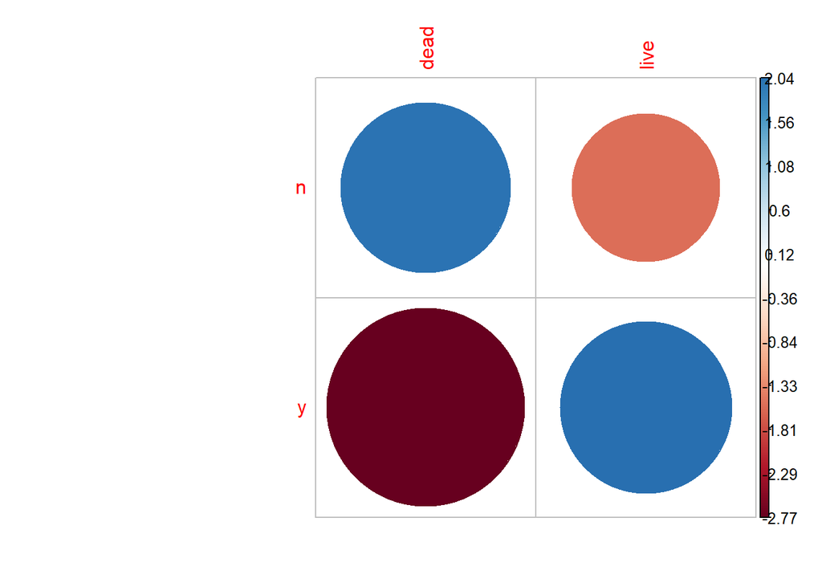

Same conclusion for female and male.

**Angina and Outcome by Sex**

Female

```
##
##  Pearson's Chi-squared test with Yates' continuity correction
##
## data:  table28.1
## X-squared = 0.21448, df = 1, p-value = 0.6433
```

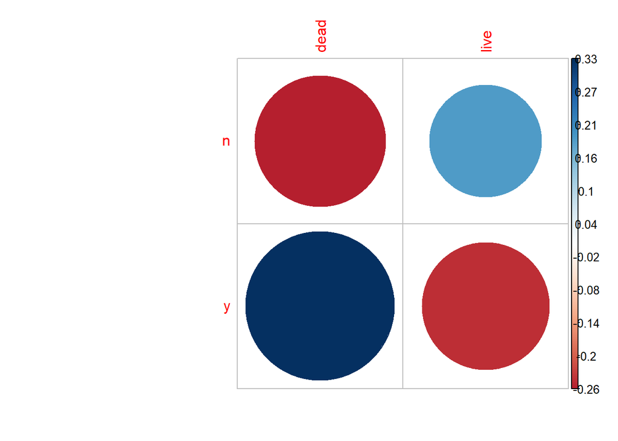

Male

```
##
##  Pearson's Chi-squared test with Yates' continuity correction
##
## data:  table28.2
## X-squared = 33.665, df = 1, p-value = 6.547e-09
```

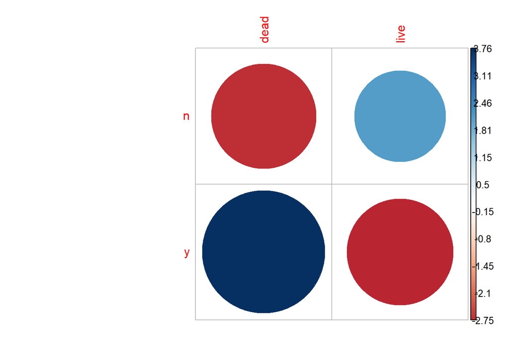

Different conclusion for female and male!

**Stroke and Outcome by Sex**

Female

```
##
##  Pearson's Chi-squared test with Yates' continuity correction
##
## data:  table29.1
## X-squared = 7.134, df = 1, p-value = 0.007564
```

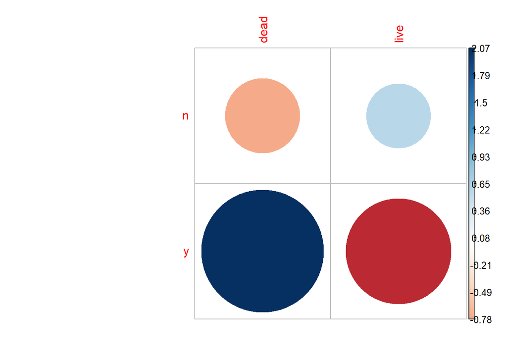

Male

```
##
##  Pearson's Chi-squared test with Yates' continuity correction
##
## data:  table29.2
## X-squared = 48.252, df = 1, p-value = 3.748e-12
```

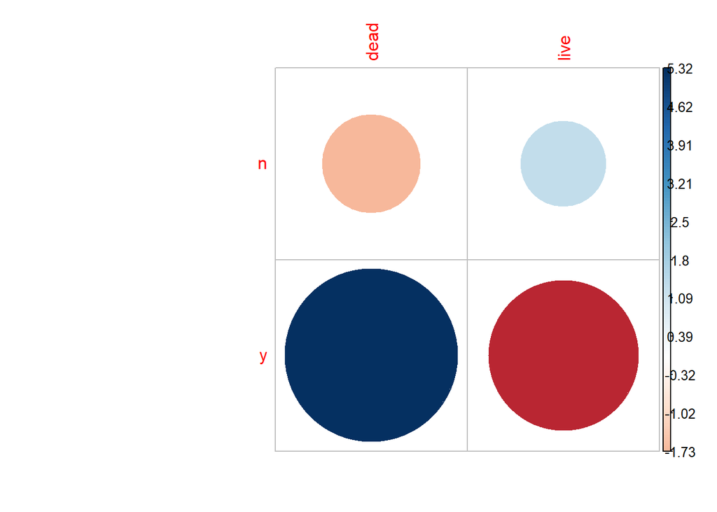

same conclusion for female and male.

**Hospitalization and Outcome by Sex**

Female

```
##
##  Pearson's Chi-squared test with Yates' continuity correction
##
## data:  table30.1
## X-squared = 778.08, df = 1, p-value < 2.2e-16
```

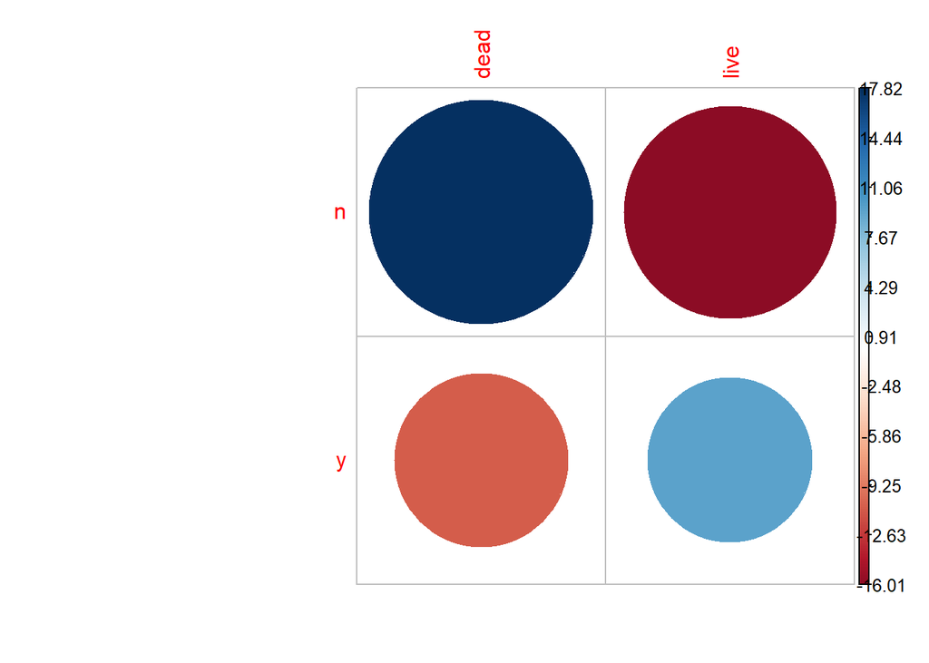

Male

```
##
##  Pearson's Chi-squared test with Yates' continuity correction
##
## data:  table30.2
## X-squared = 2631, df = 1, p-value < 2.2e-16
```

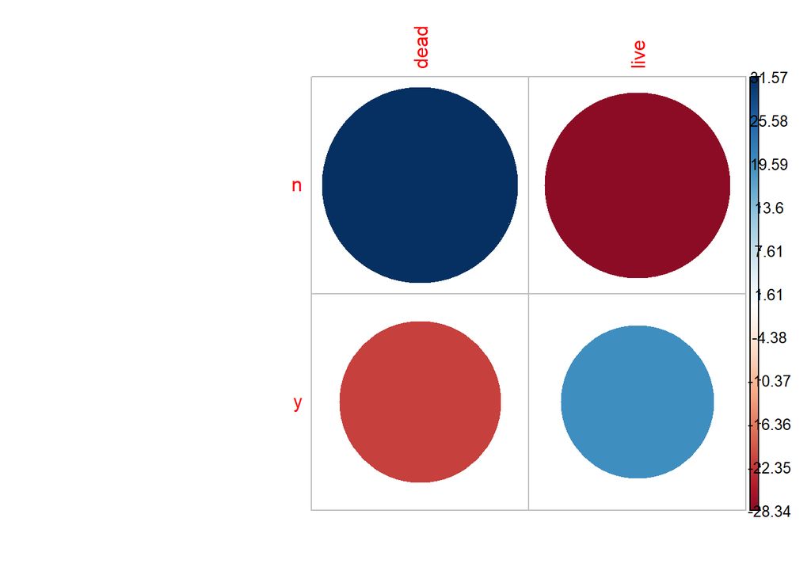

Same conclusion for female and male.

**Summary Female vs Risk factors**

[output not shown]

**Summary Male vs Risk factors**

[output not shown]

**Study of Missingness of each Feature by Sex**

```
## [1] "premi / female"
```

```
##
##    n   nk    y
## 1186  211  365
```

```
## [1] "premi / male"
```

```
##
##    n   nk    y
## 2936  523 1146
```

```
## [1] "smstat / female"
```

```
##
##   c   n  nk   x
## 498 646 282 336
```

```
## [1] "smstat / male"
```

```
##
##    c    n   nk    x
## 1553  814  636 1602
```

```
## [1] "diabetes / female"
```

```
##
##    n   nk    y
## 1197  256  309
```

```
## [1] "diabetes / male"
```

```
##
##    n   nk    y
## 3467  629  509
```

```
## [1] "highbp / female"
```

```
##
##   n  nk   y
## 515 267 980
```

```
## [1] "highbp / male"
```

```
##
##    n   nk    y
## 2027  681 1897
```

```
## [1] "hichol / female"
```

```
##
##   n  nk   y
## 860 385 517
```

```
## [1] "hichol / male"
```

```
##
##    n   nk    y
## 2434  848 1323
```

```
## [1] "angina / female"
```

```
##
##   n  nk   y
## 921 290 551
```

```
## [1] "angina / male"
```

```
##
##    n   nk    y
## 2552  685 1368
```

```
## [1] "stroke / female"
```

```
##
##    n   nk    y
## 1313  265  184
```

```
## [1] "stroke / male"
```

```
##
##    n   nk    y
## 3568  661  376
```

# Univariate analysis of numerical variables Age and Year of Onset

**Prepare Dataframe**

```
##    Min. 1st Qu.  Median    Mean 3rd Qu.    Max.
##   35.00   55.00   61.00   59.42   66.00   69.00
```

```
## (34.5,39.5] (39.5,44.5] (44.5,49.5] (49.5,54.5] (54.5,59.5] (59.5,64.5]
##         133         262         459         653        1107        1680
## (64.5,69.5]
##        2073
```

```
## 'data.frame':    6367 obs. of  13 variables:
##  $ outcome : chr  "live" "live" "live" "live" ...
##  $ sex     : chr  "f" "m" "m" "m" ...
##  $ age     : int  63 59 68 46 48 55 56 68 69 64 ...
##  $ yronset : int  85 85 85 85 85 85 85 85 85 85 ...
##  $ premi   : chr  "n" "y" "n" "n" ...
##  $ smstat  : chr  "x" "x" "n" "c" ...
##  $ diabetes: chr  "n" "n" "n" "n" ...
##  $ highbp  : chr  "y" "y" "y" "n" ...
##  $ hichol  : chr  "y" "n" "n" "n" ...
##  $ angina  : chr  "n" "n" "n" "n" ...
##  $ stroke  : chr  "n" "n" "n" "n" ...
##  $ hosp    : chr  "y" "y" "y" "y" ...
##  $ agecat  : Factor w/ 7 levels "(34.5,39.5]",..: 6 5 7 3 3 5 5 7 7 6 ...
```

```
##    Min. 1st Qu.  Median    Mean 3rd Qu.    Max.
##   85.00   87.00   89.00   88.75   91.00   93.00
```

```
## (8.45,89.5] (89.5,94.5]
##        3808        2559
```

```
## 'data.frame':    6367 obs. of  14 variables:
##  $ outcome   : chr  "live" "live" "live" "live" ...
##  $ sex       : chr  "f" "m" "m" "m" ...
##  $ age       : int  63 59 68 46 48 55 56 68 69 64 ...
##  $ yronset   : int  85 85 85 85 85 85 85 85 85 85 ...
##  $ premi     : chr  "n" "y" "n" "n" ...
##  $ smstat    : chr  "x" "x" "n" "c" ...
##  $ diabetes  : chr  "n" "n" "n" "n" ...
##  $ highbp    : chr  "y" "y" "y" "n" ...
##  $ hichol    : chr  "y" "n" "n" "n" ...
##  $ angina    : chr  "n" "n" "n" "n" ...
##  $ stroke    : chr  "n" "n" "n" "n" ...
##  $ hosp      : chr  "y" "y" "y" "y" ...
##  $ agecat    : Factor w/ 7 levels "(34.5,39.5]",..: 6 5 7 3 3 5 5 7 7 6 ...
##  $ yronsetcat: Factor w/ 2 levels "(8.45,89.5]",..: 1 1 1 1 1 1 1 1 1 1 ...
```

```
## 'data.frame':    1762 obs. of  14 variables:
##  $ outcome   : chr  "live" "live" "live" "live" ...
##  $ sex       : chr  "f" "f" "f" "f" ...
##  $ age       : int  63 55 68 64 67 66 63 68 46 66 ...
##  $ yronset   : int  85 85 85 85 85 85 85 85 85 85 ...
##  $ premi     : chr  "n" "n" "y" "n" ...
##  $ smstat    : chr  "x" "c" NA "x" ...
##  $ diabetes  : chr  "n" "n" NA "n" ...
##  $ highbp    : chr  "y" "y" "y" "y" ...
##  $ hichol    : chr  "y" "y" NA "n" ...
##  $ angina    : chr  "n" "n" "y" "y" ...
##  $ stroke    : chr  "n" "n" "n" "n" ...
##  $ hosp      : chr  "y" "y" "y" "y" ...
##  $ agecat    : Factor w/ 7 levels "(34.5,39.5]",..: 6 5 7 6 7 7 6 7 3 7 ...
##  $ yronsetcat: Factor w/ 2 levels "(8.45,89.5]",..: 1 1 1 1 1 1 1 1 1 1 ...
```

```
## 'data.frame':    4605 obs. of  14 variables:
##  $ outcome   : chr  "live" "live" "live" "dead" ...
##  $ sex       : chr  "m" "m" "m" "m" ...
##  $ age       : int  59 68 46 48 56 69 55 59 68 48 ...
##  $ yronset   : int  85 85 85 85 85 85 85 85 85 85 ...
##  $ premi     : chr  "y" "n" "n" "n" ...
##  $ smstat    : chr  "x" "n" "c" "n" ...
##  $ diabetes  : chr  "n" "n" "n" "y" ...
##  $ highbp    : chr  "y" "y" "n" "n" ...
##  $ hichol    : chr  "n" "n" "n" "n" ...
##  $ angina    : chr  "n" "n" "n" "y" ...
##  $ stroke    : chr  "n" "n" "n" "n" ...
##  $ hosp      : chr  "y" "y" "y" "y" ...
##  $ agecat    : Factor w/ 7 levels "(34.5,39.5]",..: 5 7 3 3 5 7 5 5 7 3 ...
##  $ yronsetcat: Factor w/ 2 levels "(8.45,89.5]",..: 1 1 1 1 1 1 1 1 1 1 ...
```

**Analysis of Age / Outcome and Age / Outcome Stratified by Sex**

**Age / Outcome**

```
##
##  Pearson's Chi-squared test
##
## data:  table33
## X-squared = 157.77, df = 6, p-value < 2.2e-16
```

The null hypothesis H0 is Age and Outcome are independent.

p-value is significanly smaller than 0.05.

Therefore, we reject the null hypothesis H0 and conclude that Age and Outcome are not significantly independent.

**Age / Outcome Stratified by Sex**

**Female**

```
##
##  Pearson's Chi-squared test
##
## data:  table34
## X-squared = 25.903, df = 6, p-value = 0.0002321
```

The null hypothesis H0 is Age and Outcome are independent.

p-value is significanly smaller than 0.05.

Therefore, we reject the null hypothesis H0 and conclude that Age and Outcome are not significantly independent.

**Male**

```
##
##  Pearson's Chi-squared test
##
## data:  table35
## X-squared = 149.58, df = 6, p-value < 2.2e-16
```

The null hypothesis H0 is Age and Outcome are independent.

p-value is smaller than 0.05.

Therefore, we reject the null hypothesis H0 and conclude that Age and Outcome are not significantly independent.

## Analysis of Year of Onset / outcome and Year of Onset / Outcome stratified by Sex

**Year of Onset / Outcome**

```
##
##  Pearson's Chi-squared test with Yates' continuity correction
##
## data:  table36
## X-squared = 21.295, df = 1, p-value = 3.937e-06
```

The null hypothesis H0 is Year of Onset and Outcome are independent.

p-value is significanly smaller than 0.05.

Therefore, we reject the null hypothesis H0 and conclude that Year of Onset and Outcome are not significantly independent.

**Fenale**

```
##
##  Pearson's Chi-squared test with Yates' continuity correction
##
## data:  table37
## X-squared = 5.4634, df = 1, p-value = 0.01942
```

The null hypothesis H0 is Year of Onset and Outcome are independent.

p-value is slightly smaller than 0.05.

Therefore, we reject the null hypothesis H0 and conclude that Year of Onset and Outcome are not significantly independent.

**Male**

```
##
##  Pearson's Chi-squared test with Yates' continuity correction
##
## data:  table38
## X-squared = 15.602, df = 1, p-value = 7.819e-05
```

The null hypothesis H0 is yronset and outcome are independent.

p-value is smaller than 0.05.

Therefore, we reject the null hypothesis H0 and conclude that yronset and outcome are not significantly independent.

# Univariate losgistic regression analysis (performed only on values with stastical significance):

**Results for Outcome vs Diabetes**

```
##    0    1
## 3525 2842
```

```
##               Estimate Std. Error    z value     Pr(>|z|)
## (Intercept) -0.6137656 0.03067523 -20.008510 4.643229e-89
## diabetesy    0.3132354 0.07708562   4.063474 4.834768e-05
```

**Results for Outcome vs Stroke**

```
##    0    1
## 3525 2842
```

```
##               Estimate Std. Error    z value      Pr(>|z|)
## (Intercept) -0.6473935 0.03013988 -21.479630 2.414204e-102
## strokey      0.6473935 0.08972887   7.214997  5.393501e-13
```

**Results for Outcome vs Angina**

```
##    0    1
## 3525 2842
```

```
##               Estimate Std. Error    z value     Pr(>|z|)
## (Intercept) -0.6914201 0.03598561 -19.213791 2.837679e-82
## anginay      0.3063240 0.05880155   5.209455 1.893963e-07
```

**Results for Outcome vs High Cholesterol**

```
##    0    1
## 3525 2842
```

```
##               Estimate Std. Error   z value     Pr(>|z|)
## (Intercept) -0.4315921 0.03566176 -12.10238 1.025937e-33
## hicholy     -0.4002255 0.06199923  -6.45533 1.079830e-10
```

**Results for Outcome vs Hospitalization**

```
##    0    1
## 3525 2842
```

```
##              Estimate Std. Error   z value     Pr(>|z|)
## (Intercept)  6.462503  0.5767778  11.20449 3.875687e-29
## hospy       -7.804914  0.5779650 -13.50413 1.478541e-41
```

**Results for Outcome vs Previous Myocardial Infraction event**

```
##    0    1
## 3525 2842
```

```
##               Estimate Std. Error    z value     Pr(>|z|)
## (Intercept) -0.5417412 0.03230109 -16.771607 3.937121e-63
## premiy       0.1982307 0.06139608   3.228719 1.243461e-03
```